# Machine Learning Course Project Part 1

First download the data dn examine the general characteristics of the dat wit str function.

The results reveal that there are a lot of columns that do not hold information. These columns will be eliminated from the data set.

```r
library(caret)
library(randomForest)
library(AppliedPredictiveModeling)
library(gbm)
library(rpart)
library(rattle)
```

```r
library(rpart.plot)
set.seed(100)
trainingdata<-read.csv("C:/Users/MustafaErgin/Desktop/R Studies/Machine Learning/pml-training.csv",na.strings = c("NA", "#DIV/0!", ""))
testingdata<-read.csv("C:/Users/MustafaErgin/Desktop/R Studies/Machine Learning/pml-testing.csv",na.strings = c("NA", "#DIV/0!", ""))
str(trainingdata)
```

```
## 'data.frame':    19622 obs. of  160 variables:
##  $ X                       : int  1 2 3 4 5 6 7 8 9 10 ...
##  $ user_name               : Factor w/ 6 levels "adelmo","carlitos",..: 2 2 2 2 2 2 2 2 2 2 ...
##  $ raw_timestamp_part_1    : int  1323084231 1323084231 1323084231 1323084232 1323084232 1323084232 1323084232 1323084232 1323084232 1323084232 ...
##  $ raw_timestamp_part_2    : int  788290 808298 820366 120339 196328 304277 368296 440390 484323 484434 ...
##  $ cvtd_timestamp          : Factor w/ 20 levels "02/12/2011 13:32",..: 9 9 9 9 9 9 9 9 9 9 ...
##  $ new_window              : Factor w/ 2 levels "no","yes": 1 1 1 1 1 1 1 1 1 1 ...
##  $ num_window              : int  11 11 11 12 12 12 12 12 12 12 ...
##  $ roll_belt               : num  1.41 1.41 1.42 1.48 1.48 1.45 1.42 1.42 1.43 1.45 ...
##  $ pitch_belt              : num  8.07 8.07 8.07 8.05 8.07 8.06 8.09 8.13 8.16 8.17 ...
##  $ yaw_belt                : num  -94.4 -94.4 -94.4 -94.4 -94.4 -94.4 -94.4 -94.4 -94.4 -94.4 ...
##  $ total_accel_belt        : int  3 3 3 3 3 3 3 3 3 3 ...
##  $ kurtosis_roll_belt      : num  NA NA NA NA NA NA NA NA NA NA ...
##  $ kurtosis_picth_belt     : num  NA NA NA NA NA NA NA NA NA NA ...
##  $ kurtosis_yaw_belt       : logi  NA NA NA NA NA NA ...
```

[output cut: 86 more lines]

```r
anydata  <- apply(!is.na(trainingdata), 2, sum) > 19621  # which is the number of observations
trainingdata <- trainingdata[, anydata]
testingdata  <- testingdata[, anydata]
```

*** Method 1: Split the training data into training and testing (for validation purposes)

The rule of thumb 60:40 split is used to divide the trainingdata into another training and validation data sets.

First boosting is tried. However the relative influence table did only reveal 2 variables as the key variables. As a result and rpart model is being created to see if actually this looks healthy.

```
## Distribution not specified, assuming multinomial ...
```

```
## n.trees not given. Using 1000 trees.
```

```
##                    X       cvtd_timestamp     magnet_forearm_z
##           1.00000000           0.03068354           0.00000000
##     magnet_forearm_y     magnet_forearm_x      accel_forearm_z
##           0.00000000           0.00000000           0.00000000
##      accel_forearm_y      accel_forearm_x      gyros_forearm_z
##           0.00000000           0.00000000           0.00000000
##      gyros_forearm_y      gyros_forearm_x  total_accel_forearm
##           0.00000000           0.00000000           0.00000000
##          yaw_forearm        pitch_forearm         roll_forearm
##           0.00000000           0.00000000           0.00000000
##    magnet_dumbbell_z    magnet_dumbbell_y    magnet_dumbbell_x
##           0.00000000           0.00000000           0.00000000
##     accel_dumbbell_z     accel_dumbbell_y     accel_dumbbell_x
##           0.00000000           0.00000000           0.00000000
##     gyros_dumbbell_z     gyros_dumbbell_y     gyros_dumbbell_x
##           0.00000000           0.00000000           0.00000000
## total_accel_dumbbell         yaw_dumbbell       pitch_dumbbell
##           0.00000000           0.00000000           0.00000000
##        roll_dumbbell         magnet_arm_z         magnet_arm_y
##           0.00000000           0.00000000           0.00000000
##         magnet_arm_x          accel_arm_z          accel_arm_y
##           0.00000000           0.00000000           0.00000000
##          accel_arm_x          gyros_arm_z          gyros_arm_y
##           0.00000000           0.00000000           0.00000000
##          gyros_arm_x      total_accel_arm              yaw_arm
##           0.00000000           0.00000000           0.00000000
##            pitch_arm             roll_arm        magnet_belt_z
##           0.00000000           0.00000000           0.00000000
##        magnet_belt_y        magnet_belt_x         accel_belt_z
##           0.00000000           0.00000000           0.00000000
##         accel_belt_y         accel_belt_x         gyros_belt_z
##           0.00000000           0.00000000           0.00000000
##         gyros_belt_y         gyros_belt_x     total_accel_belt
##           0.00000000           0.00000000           0.00000000
##             yaw_belt           pitch_belt            roll_belt
##           0.00000000           0.00000000           0.00000000
##           num_window           new_window raw_timestamp_part_2
##           0.00000000           0.00000000           0.00000000
## raw_timestamp_part_1            user_name
##           0.00000000           0.00000000
```

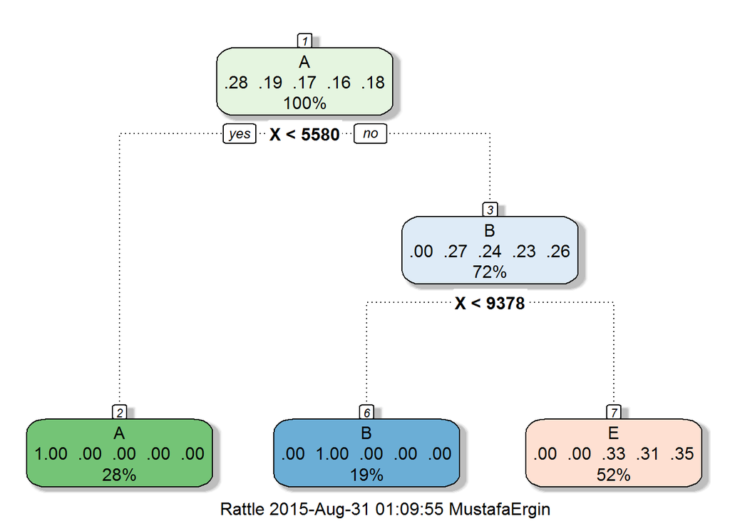

```
##                               A         B         C         D         E
## X                    27.3344648 27.616174 33.280725 29.114511 29.893376
## user_name             5.2633274  7.590305  6.904614  6.424912  6.785221
## raw_timestamp_part_1 12.8526383 19.623494 20.704784 19.642694 18.306866
## raw_timestamp_part_2  0.5439633  3.632624  4.234137  2.259283  2.458124
## cvtd_timestamp       14.5205585 22.889388 27.052316 25.285385 22.899523
## new_window            0.0000000  0.000000 -1.002509 -1.002509  0.000000
## num_window            8.9605156 13.264911 14.466773 12.431730 11.156159
## roll_belt             9.0701862 13.733599 13.222398 16.121262 13.639150
## pitch_belt            6.8469995 12.627539 12.785616 12.630818 11.184430
## yaw_belt              8.0695289 11.877268 12.329511 13.998067  9.160299
## total_accel_belt      4.7223060  6.458494  5.864482  6.828833  5.662682
## gyros_belt_x          3.8612668  4.808085  6.827350  4.965423  5.391279
## gyros_belt_y          3.5944890  5.355546  5.295017  5.650323  4.911558
## gyros_belt_z          5.9152227  7.636939  9.336098  8.925015  7.958493
## accel_belt_x          4.4540451  5.626841  7.320769  7.480241  6.808566
## accel_belt_y          3.2015098  5.357047  5.433932  6.203446  5.015916
## accel_belt_z          6.5389737  8.415512  9.850598  9.197366  8.086375
## magnet_belt_x         5.0736297  7.956429  8.920321  8.231436  8.425243
## magnet_belt_y         6.7611793  9.156229  9.481894 12.013507 10.341831
## magnet_belt_z         6.4748346  9.127831  9.777027 11.881952  9.072299
## roll_arm              5.9626837  8.625920  8.725974  8.545300  7.714094
## pitch_arm             4.0084241  7.950918  6.867776  6.656438  6.068387
## yaw_arm               4.9161716  7.120309  7.445688  8.368993  5.596055
## total_accel_arm       3.4865444  5.766382  5.367098  4.647606  5.548138
## gyros_arm_x           3.8862740  5.543637  6.983332  7.043825  5.349921
## gyros_arm_y           4.1598612  8.467897  8.068463  7.867431  4.993718
## gyros_arm_z           2.6376441  4.403258  4.171836  3.868507  4.298804
## accel_arm_x           5.1079604  6.274843  6.945591  7.619083  5.533954
## accel_arm_y           3.8805073  5.625719  5.046876  4.984853  5.891902
## accel_arm_z           5.0492187  7.122808  6.532064  5.878553  5.869684
## magnet_arm_x          5.2152711  5.871900  6.161129  5.280397  4.949313
## magnet_arm_y          4.1793462  5.362825  7.646631  7.232461  4.672907
## magnet_arm_z          5.5033390  9.223027  6.173391  7.352746  7.347104
## roll_dumbbell         5.8519000  9.033572 11.030154  9.942235  8.690334
## pitch_dumbbell        4.7233736  7.917704  7.156014  5.908119  5.776878
## yaw_dumbbell          4.9713614  7.864358  8.139565  8.522412  7.258437
## total_accel_dumbbell  5.7780318  8.545464  8.583223  7.495040  7.170067
## gyros_dumbbell_x      3.8526028  7.769837  8.158475  6.465932  5.680453
## gyros_dumbbell_y      7.0249814  8.724181  9.942103  9.017477  6.768921
```

[output cut: 65 more lines]

```
## magnet_dumbbell_y               12.809248     2.137680e+02
## magnet_dumbbell_z               13.146188     1.822777e+02
## roll_forearm                     8.667192     1.290580e+02
## pitch_forearm                   14.488721     2.065620e+02
## yaw_forearm                      9.897960     2.890061e+01
## total_accel_forearm              6.801028     2.043299e+01
## gyros_forearm_x                  7.864923     1.257188e+01
## gyros_forearm_y                 12.414531     2.640510e+01
## gyros_forearm_z                  9.592289     1.767725e+01
## accel_forearm_x                  9.648319     7.972459e+01
## accel_forearm_y                  6.572111     2.188425e+01
## accel_forearm_z                  9.534258     6.108894e+01
## magnet_forearm_x                 8.798623     4.366650e+01
## magnet_forearm_y                10.996839     3.957858e+01
## magnet_forearm_z                13.115219     4.810426e+01
```

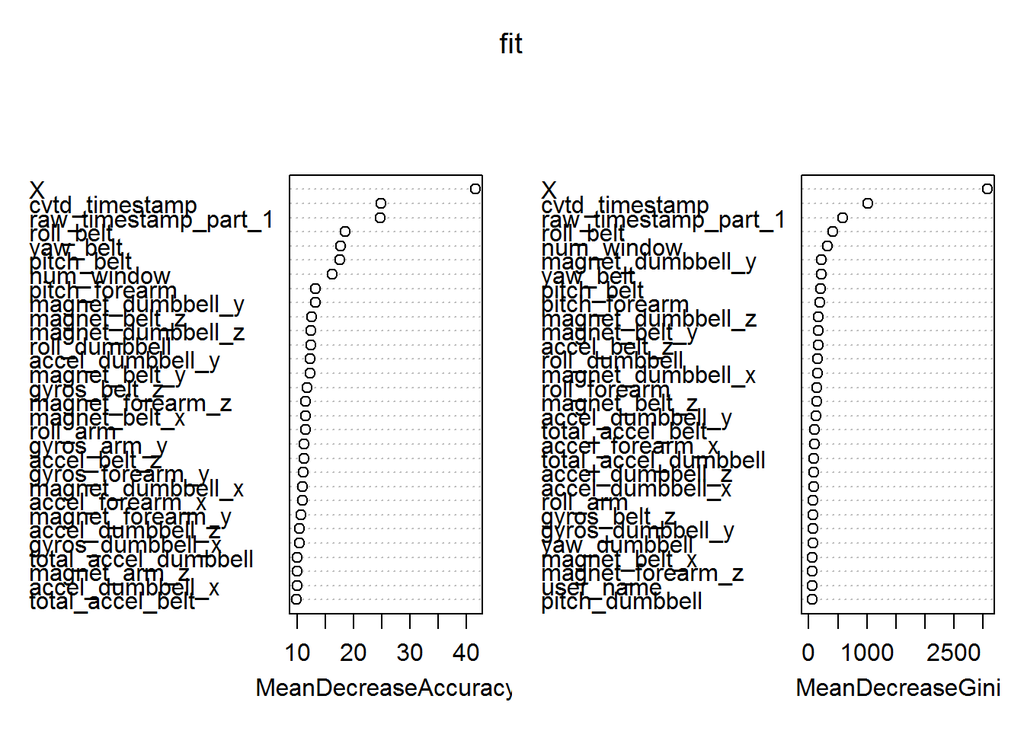

It takes a considerable amount of time(around 15 min) to be able to run the random forest with all variables As a result, it is decided to limit the variables to get the answer. As a result of the variable importance graphs, 7 variables are selected to be the representing variables since they seem to be enough to explain much more than the remaining variables. (around 95 impact)

These vaiables are: “X, raw_timestamp_part_1, cvtd_timestamp, roll_belt,yaw_belt,num_window ,pitch_belt”"

As a result now it is decided to continue with random forest and used a k=2. That resulted in a 2 minutes runtime.

```
## Confusion Matrix and Statistics
##
##           Reference
## Prediction    A    B    C    D    E
##          A 2232    0    0    0    0
##          B    0 1518    0    0    0
##          C    0    0 1368    0    0
##          D    0    0    0 1286    0
##          E    0    0    0    0 1442
##
## Overall Statistics
##
##                Accuracy : 1
##                  95% CI : (0.9995, 1)
##     No Information Rate : 0.2845
##     P-Value [Acc > NIR] : < 2.2e-16
##
##                   Kappa : 1
##  Mcnemar's Test P-Value : NA
##
## Statistics by Class:
##
##                      Class: A Class: B Class: C Class: D Class: E
## Sensitivity            1.0000   1.0000   1.0000   1.0000   1.0000
## Specificity            1.0000   1.0000   1.0000   1.0000   1.0000
## Pos Pred Value         1.0000   1.0000   1.0000   1.0000   1.0000
## Neg Pred Value         1.0000   1.0000   1.0000   1.0000   1.0000
## Prevalence             0.2845   0.1935   0.1744   0.1639   0.1838
## Detection Rate         0.2845   0.1935   0.1744   0.1639   0.1838
## Detection Prevalence   0.2845   0.1935   0.1744   0.1639   0.1838
## Balanced Accuracy      1.0000   1.0000   1.0000   1.0000   1.0000
```